# Why Do RSL Fans Cheer Longer Than Utah Jazz Fans?

Tom Coe, Joey Brignone, Darren Rou

April 29, 2022

# 1 Introduction

If you’ve ever been to a MLS game you know the crowd goes crazy when their team scores a goal. In comparison at an NBA game the crowd cheers, but without the same amount of enthusiasm. This study aims to look into this phenomenon and see if we can find important factors that contribute to this. The hypothesis of this study is that the amount of time a crowd cheers is dependent on the number of points scored per game. To investigate this question we will look at Utah’s professional soccer and basketball teams Real Salt Lake (RSL) and the Utah Jazz. First we will collect data on the total points scored for these teams. Then, we will collect data on how long each team’s respective crowd cheers when they score a point. We will then compare these values and see if there is any connection between them.

# 2 Data Discovery

## 2.1 Scoring Data

[nba.com](https://www.nba.com/stats/teams/boxscores/?Season=2020-21&SeasonType=Regular%20Season&CF=TEAM_NAME*E*Utah%20Jazz) provides scoring data for NBA teams. This website allows filtering of data by team, season, and the type of game (regular, playoffs, etc.). We note that there aren’t many playoff games for the Jazz. With this taken into consideration, we choose to take all scoring data from playoff, play-in, and regular season games. We do so with the assumption that games scores do not depend on the type of game. This assumption is reasonable for our purposes. We are interested in the total points scored by the Utah Jazz each game.

We repeat the same process of the RSL. Data is conveniently available from Google searches. We collect data about the total points scored each game.

## 2.2 Cheering Data

To collect data, we watched RSL and Jazz games and observed the crowd when there was an instance of scoring. Then, using a stopwatch we timed the duration of the crowd’s cheering. For the basketball games this was simple as there are no cuts in the video feed, but for soccer game this was a little harder. Since there is a delay in game play after a goal is scored in soccer the broadcasting network cuts away from the live feed and shows instant replays. These replays, however, still have live audio from the commentators and the crowd can still be heard. Thus, to gather data for the celebration time we focused on listening to the crowd during the replays and did our best to estimate when the crowd had stopped cheering. The act of timing the crowd’s reaction introduces error in itself, but the added difficulty of not having a single continuous video feed made accurate data collection even more difficult.

Our samples each consist of 50 data points. For the Jazz games we chose 5 random instances of scoring out of 10 different games that were also chosen at random between 2021-2022. We also noticed a change in the crowds cheering between home and away games so we chose an even number, 5 home games and 5 away games, to collect data from. The soccer games were harder to find and for this reason we essentially chose all of the games that we could find video on. Most of these were also from the 2021-2022 season.

# 3 Methodology

After data collection, we were given many measurements to choose from. The first population sample we wish to evaluate will be the scores per game. In order to adequately answer our question we will first analyze how much one point in soccer is compared to one point in basketball. We will need to take the scoring data collected and compare the means of each data set. To do this we will assume these data sets follow a normal distribution and will use t-tests to construct confidence intervals to approximate the value of the population means. Since we are fairly confident in our data, yet we recognize possible biases that are present, we will be using a confidence interval of 95%. Through this t-test of 95% confidence, we can find a range for the population mean for the scores per game of RSL and of the Jazz.

Next, we wish to use this information to see why RSL fans cheer longer than Jazz Fans. From our data sets, we will take the sample of cheer time per point, plot a histogram and normal curve, and analyze our results. This should prepare us to run another t-test of this sample, to find a range wherein lies the population mean. For consistency, we will use the 95% confidence interval from before. Once both t-tests are run for both cheer time data sets, we may start to draw conclusions from our results.

One experimental parameter is this important is the sample size. It is conventional to have a sample size of 30 or greater. We will consider the t-scores which arises from using a sample size of 50. For sample size of 50 and a 95% confidence interval. The result is 2.0095752. This is a good value for our experiment. This number means we have a 95% chance, that our sample mean will be within about 2 standard deviations of the true population mean.

We will now consider what 2 t-scores means in terms of fans’ celebration time. We will use external knowledge of sports games. Using our knowledge of sports games, we can say that the standard deviation of fans’ celebration times is probably much lower than 60 seconds. We will use 60 seconds as the standard deviation as a worse case scenario. In terms of a t-score of 2, we have an estimated EBM of

$$2 \frac{60}{\sqrt{50}}$$

which evaluates to 16.9705627. Considering that 60 is probably much higher than the true value, this value is not bad. For example, if instead the standard deviation was a more reasonable value, say, around 10, then we would have gotten 2.8284271 as our EBM.

In other words, in a bad case (standard deviation of around 60 seconds), the width of our confidence interval will be about twice 16.9705627 or about 34 seconds. In a good case (standard deviation of about 10 seconds), the width of our confidence interval will be about twice 2.8284271 or about 5.7 seconds. Considering all of this, we will decide that a sample size of 50 (or greater) with our constructed 95% confidence interval is suitable for our experiment.

# 4 Analysis

## 4.1 One RSL Point Is Worth X Utah Jazz Points

### 4.1.1 Utah Jazz Point Analysis

One RSL point is worth how many Utah Jazz points? To answer this question, we consider the total points scored by the Jazz each game in the 2019–2020 and 2020–2021 seasons. We put this data into a `.csv` file, and using the `head()` function, we can create a table to see what it looks like:

| Team | Match Up | Game Date | W/L | Min | Points |
| --- | --- | --- | --- | --- | --- |
| UTA | UTA @ LAC | 06/18/2021 | L | 240 | 119 |
| UTA | UTA vs. LAC | 06/16/2021 | L | 240 | 111 |
| UTA | UTA @ LAC | 06/14/2021 | L | 240 | 104 |
| UTA | UTA @ LAC | 06/12/2021 | L | 240 | 106 |
| UTA | UTA vs. LAC | 06/10/2021 | W | 240 | 117 |
| UTA | UTA vs. LAC | 06/08/2021 | W | 240 | 112 |

As we can see, the `Points` column corresponds to total points scored by the Jazz during a game.

The population we would like to consider consists of all points scored by the Jazz in a game. Our sample (shown earlier) represents only a small portion of the population, but it is sufficient for the motivation for this study. We will now do some basic analysis on the data.

```
##    Min. 1st Qu.  Median    Mean 3rd Qu.    Max.
##      78     106     114     114     122     154
```

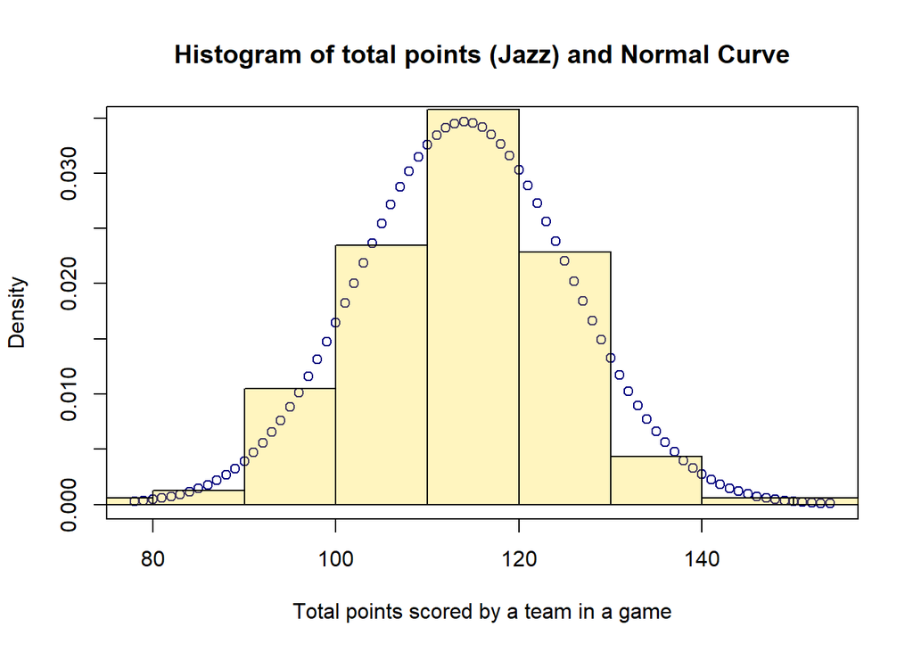

The previous histogram had a sample size of 162. We find the sample mean to be 114.0432099 and the sample standard deviation to be 11.5163124. As shown by the previous histogram, the data is approximately normal, and using a t-distribution for analysis is suitable.

```
##
##  One Sample t-test
##
## data:  nbaScores
## t = 126.04, df = 161, p-value < 2.2e-16
## alternative hypothesis: true mean is not equal to 0
## 95 percent confidence interval:
##  112.2564 115.8300
## sample estimates:
## mean of x
##  114.0432
```

The previous t-test gives a 95% confidence interval of (112.2563898, 115.83003). In terms of NBA scores, this interval is quite small. Our analysis shows that we have good evidence that the population mean of Jazz scores is within these bounds.

Note that we only sampled from the 2019–2020 and 2020–2021 seasons. It is reasonable to say that sample from these recent seasons may not be representative of the populations. However, sports fans may care more about the current state of their favorite teams rather than what their favorite team was like many years ago. Because of this using data from recent years can actually give more relevant results—as far as sports fans are concerned.

### 4.1.2 RSL Point Analysis

Now, we consider data for RSL. Similar to our Jazz analysis, we want to consider the total points scored by the RSL in a game.

| Team | Final Score | Year |
| --- | --- | --- |
| RSL | 0 | 2022 |
| RSL | 0 | 2022 |
| RSL | 2 | 2022 |
| RSL | 1 | 2022 |
| RSL | 0 | 2022 |
| RSL | 2 | 2022 |

Above is a table representing the data retrieved in the 2021-2022 season, from google.com. The column we are interested in for our study’s purposes is the `Final Score`.

Similar to before, we consider be the total number of points scored by the RSL in a game.

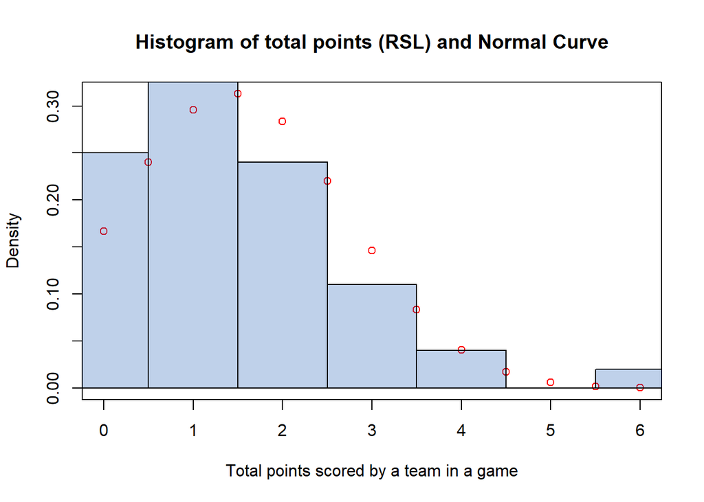

```
##
##  One Sample t-test
##
## data:  mlsScores
## t = 11.231, df = 99, p-value < 2.2e-16
## alternative hypothesis: true mean is not equal to 0
## 95 percent confidence interval:
##  1.177348 1.682652
## sample estimates:
## mean of x
##      1.43
```

Using a t-test, we find a 95% confidence interval of (1.1773481, 1.6826519).

As with the Jazz case, our data for RSL scores may be biased, but it should be sufficient for our purposes. Although it seems obvious that our means are significantly different, we can do a two variable t-test to confirm this.

```
##
##  Welch Two Sample t-test
##
## data:  nbaScores and mlsScores
## t = 123.25, df = 167.33, p-value < 2.2e-16
## alternative hypothesis: true difference in means is not equal to 0
## 95 percent confidence interval:
##  110.8093 114.4171
## sample estimates:
## mean of x mean of y
##  114.0432    1.4300
```

The previous t-test suggests that NBA games have much higher scores than MLS games. The p-value is orders of magnitude lower than .05. Because of this fans may feel like points in MLS games are harder to obtain and therefore cheer longer. We will now compare the ranges of population means for Jazz games and RSL games that we derived with our t-tests.

The low end of the Jazz scoring mean is 112.2563898 and the high end of the mean for RSL is 1.6826519. We will create a ratio by dividing these by each other. This will show us the lowest ratio between our population means. We will also compute this ratio for the high end of the interval by using the upper bound of the Jazz means and the lower bound of the RSL mean. This will give us the maximum ratio between these two means.

After these calculation we arrived at a ratio of 66.71397 for the lower bound and 98.3821455 for the higher bound. This means that we have decently strong evidence that on average one point scored by RSL is at least equivalent to 66.71397 Jazz points and at most equivalent to 98.3821455 Jazz points. This difference is much bigger than we had anticipated. This is partially due to MLS games ending with zero points. Sometimes games end with zero points between either team. The minimum score we recorded for a Jazz game was 78 points. This number is still 13 times higher than RSL’s maximum score of 6.

## 4.2 How Long Do RSL Fans Cheer Compared to Jazz Fans

### 4.2.1 Utah Jazz Fan Analysis

Next, we will see if the cheering times between fans of RSL and the Utah Jazz are significantly different. First, we will take the data we collected and compute the mean values for each. Similar to what we did in the previous section for the scoring data.

| Opposing Team | Year | Game Time | Point # | Celebration Time | Location |
| --- | --- | --- | --- | --- | --- |
| LA Lakers | 2021 | 10:25 | 24 | 6.98 | home |
| LA Lakers | 2021 | 6:54 | 13 | 7.02 | home |
| LA Lakers | 2021 | 22:47 | 60 | 10.00 | home |
| LA Lakers | 2021 | 11:36 | 72 | 7.63 | home |
| LA Lakers | 2021 | 20:13 | 105 | 10.65 | home |
| Milwaukee Bucks | 2021 | 4:52 | 15 | 6.62 | home |

The table above shows the variables we tracked when watching Jazz games. The variable we are most interested in for this study is `Celebration Time`. Here are some summary statistics for the celebration times:

```
##    Min. 1st Qu.  Median    Mean 3rd Qu.    Max.
##   1.820   3.030   4.400   5.108   6.628  10.650
```

Next we will use this data and create a histogram.

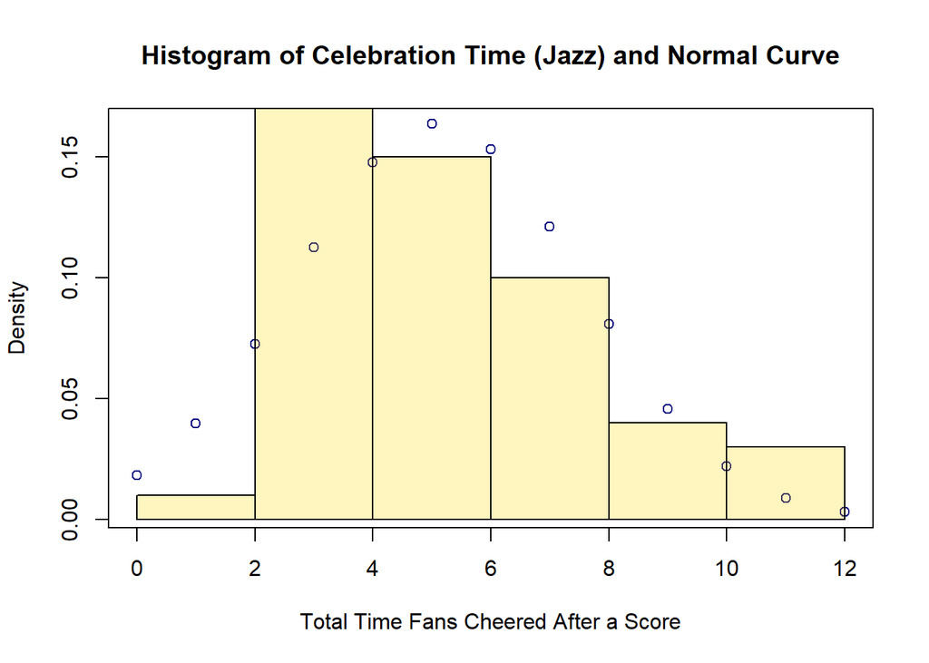

Here we have created a histogram of our cheering data for Utah Jazz fans. We observe this follows close enough to a normal distribution to perform a t-test. Therefore, we will conduct a t-test with a 95% confidence interval to provide good evidence to the range of the population mean.

```
##
##  One Sample t-test
##
## data:  jazzCelebrationTimes
## t = 14.828, df = 49, p-value < 2.2e-16
## alternative hypothesis: true mean is not equal to 0
## 95 percent confidence interval:
##  4.41557 5.80003
## sample estimates:
## mean of x
##    5.1078
```

From this t-test we have observed with 95% confidence the population mean will be within (4.4155696, 5.8000304) seconds. Now we will do this same analysis on the RSL fan data.

### 4.2.2 RSL Fan Analysis

| Opposing Team | Year | Game Time | Point # | Celebration Time | Location |
| --- | --- | --- | --- | --- | --- |
| Sporting Kansas City | 2021 | 23:57 | 1 | 35.70 | away |
| Sporting Kansas City | 2021 | 18:24 | 2 | 43.40 | away |
| Minnesota United | 2021 | 6:42 | 1 | 24.20 | home |
| Los Angeles FC | 2018 | 20:31 | 1 | 21.59 | away |
| Los Angeles FC | 2018 | 9:57 | 2 | 25.64 | away |
| Los Angeles FC | 2018 | 20:54 | 3 | 38.67 | away |

Just like the Jazz fan data we have tracked variables of opposing team, year, game time, point number, celebration time, and location. We will be focusing on the celebration time in this analysis. First we will calculate mean and standard deviation values. Then we will use these values to create a normal curve distribution and overlay this with a histogram from our data.

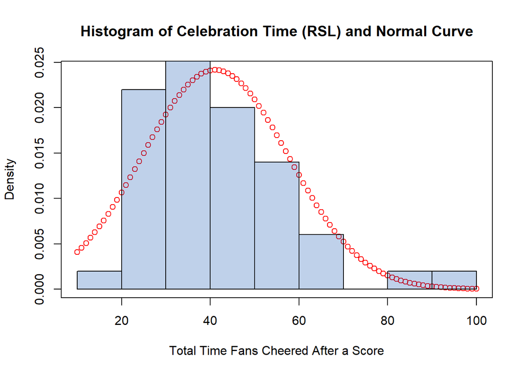

The histogram of our RSL fan data seems to line up decently with a normal distribution. It is shifted a little to the left and has a couple outliers on the right side. This is probably due to some factors such as a game winning goal late into the game. Next, we will conduct a t-test with a 95% confidence interval as we have done with the Jazz fan data.

```
##
##  One Sample t-test
##
## data:  rslCelebrationTimes
## t = 17.62, df = 49, p-value < 2.2e-16
## alternative hypothesis: true mean is not equal to 0
## 95 percent confidence interval:
##  36.4379 45.8197
## sample estimates:
## mean of x
##   41.1288
```

From this t-test we have observed with 95% confidence the population mean will be within (36.4379047, 45.8196953) seconds.

Next, we will perform a two-variable t-test using a 95% confidence level to determine if there is a difference between Jazz fans’ celebration times and RSL fans’ celebration times.

```
##
##  Welch Two Sample t-test
##
## data:  jazzCelebrationTimes and rslCelebrationTimes
## t = -15.266, df = 51.133, p-value < 2.2e-16
## alternative hypothesis: true difference in means is not equal to 0
## 95 percent confidence interval:
##  -40.7577 -31.2843
## sample estimates:
## mean of x mean of y
##    5.1078   41.1288
```

As we can see from the previous t-test, our p-value is much lower than .05. We believe this is very strong evidence that the population means are significantly different. The 95% confidence interval for this t-test is (-40.7576978, -31.2843022). This confidence interval says that on average, Jazz fans’ celebration time are shorter than RSL fans’ celebration time. Using this data we can create a ratio of how long Jazz fans cheer versus RSL fans. This is similar to what we did with the point analysis.

After these calculation we arrived at a ratio of 6.2823644 for the lower bound and 10.3768481 for the higher bound. This means that we have decently strong evidence that on average RSL fans cheer 6.2823644 times longer and at most 10.3768481 times longer when RSL scores a point.

## 4.3 Other Interesting Variables

### 4.3.1 Investigating Point Number Correlations

From our analysis we have asked ourselves if the point number is directly correlated with the amount of cheering. Meaning do fans cheer longer for points towards the end of the game. To investigate further we compared the point number to the cheering time of both Jazz and RSL fans.

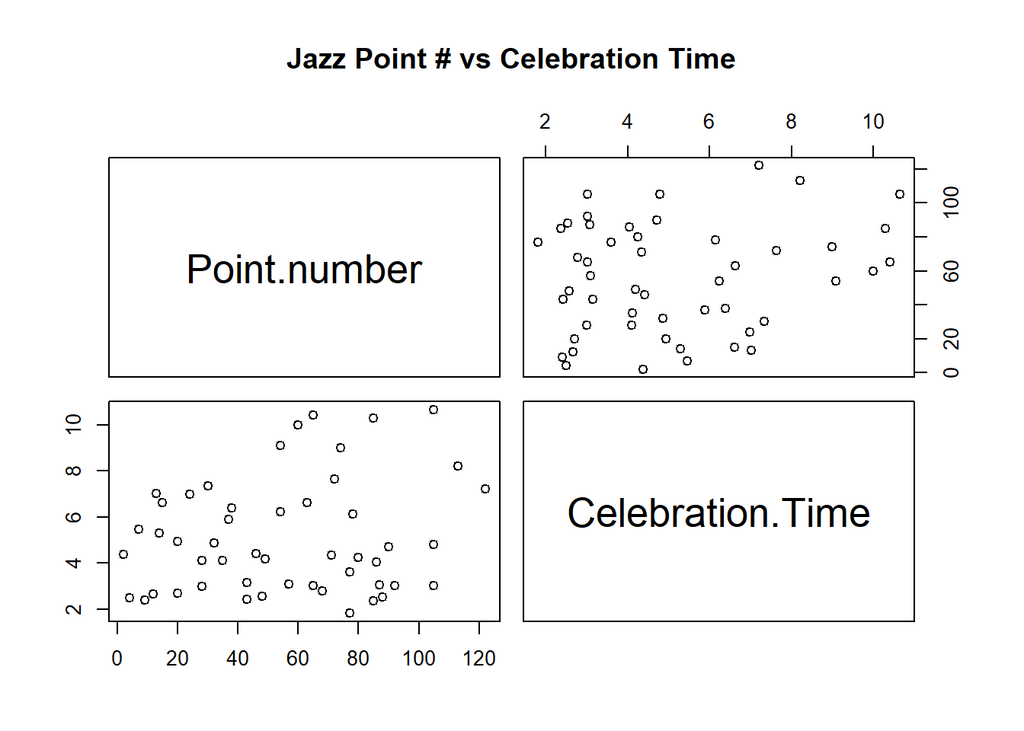

```r
pairs(jazzData[,4:5],main = "Jazz Point # vs Celebration Time")
```

Seen above are the `Point #` versus `Celebration Time` scatter plots for the Jazz fan data. We see there could be a very weak correlation, but point number seems to have little to no influence on celebration time.

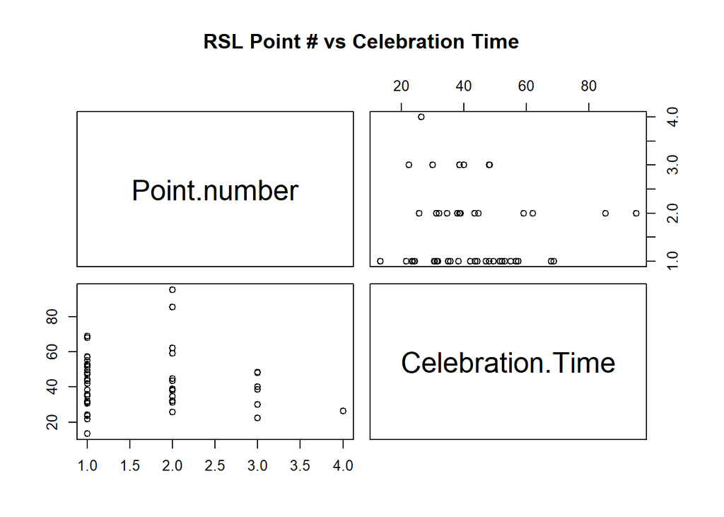

```r
pairs(rslData[,4:5],main = "RSL Point # vs Celebration Time")
```

Above we performed the same analysis for the RSL fan data. Here we see slightly elevated cheering times for the second point scored. Perhaps this is because this point is the most influential in RSL games, but there doesn’t seem to be any meaningful correlations between point number and celebration time for RSL fans.

### 4.3.2 Investigating Home Versus Away Games

Another factor that seemed to play a significant roll was whether the team was playing a home versus away game. This would make sense as the team has more local support at a home game and therefore the crowd might cheer longer.

```r
jazzHvA <- jazzData %>% group_by(location) %>% summarise(mean(Celebration.Time))
knitr::kable(jazzHvA,col.names=c('Location','Celebration Time, (s)'),align='c') %>%
  kable_styling(full_width = T)
```

| Location | Celebration Time, (s) |
| --- | --- |
| away | 3.2740 |
| home | 6.9416 |

Similarly for RSL:

```r
rslHvA <- rslData %>% group_by(location) %>% summarise(mean(Celebration.Time))
knitr::kable(rslHvA,col.names=c('Location','Celebration Time, (s)'),align='c') %>%
  kable_styling(full_width = T)
```

| Location | Celebration Time, (s) |
| --- | --- |
| away | 31.80043 |
| home | 49.07519 |

Again, we see a significant difference between home and away game celebration times. Our sample mean for the RSL home games was about 49 seconds. This is about 17.2 seconds higher than the sample mean of our away games at 31.8 seconds.

# 5 Limitations

As discussed earlier, the data we have gathered is not totally random. However, it is possible that the data we have good is somewhat good at representing the underlying populations. We tried to get random data as much as possible, but we ran into issues such as sports games being unavailable for viewing. To alleviate these problems, we gathered data from different games. Additionally, our large sample size of 50 for both Jazz and RSL helped make the data more representative.

There is also the matter of date. All our data come from sports games which have taken place in the past few years. In the context of our question, it could be argued that gathering data from a wide range of years may have been better. However, it is also reasonable to say that data from recent years is more relevant to most people—sports fans may not care too much about what happened decades ago, and they may be more interested in data from recent years.

# 6 Conclusion

In this study we have investigated the difference in points scored for RSL and Utah Jazz teams. Our hypothesis was that this increase in score was significant and that in turn RSL fans cheered longer than Jazz fans. We found decently strong evidence that 1 RSL point is worth 66.7 - 98.4 Utah Jazz points. This is a huge discrepancy. Meanwhile, we found decently strong evidence that RSL fans cheer 6.3 to 10.4 times longer than Jazz fans. This makes sense because essentially for every goal the RSL scores this is equivalent to 67-98 point in a Jazz game. If anything it seems RSL fans should be cheering even longer, but there are other limitations like vocal cords giving out and play resuming.

We also found a few other interesting variables that affect cheering during our analysis. The first being point number. You would assume that the longer the game goes on and point number increases that the fans would start to cheer longer. According to our analysis there wasn’t much evidence to show this. At best in Jazz games there is a very weak correlation between cheering time and point number. Our RSL analysis showed no correlation. If anything RSL fans cheered the most for the second goal. This is potentially the most significant goal in a soccer match.

Lastly, we looked at how being a home game and away game affected cheering time. We found this to be pretty substantial. The mean cheering time for Utah Jazz fans at an away game was only 3.27 seconds on average for our sample, but for a home game was 6.94 seconds. This is more than double our sample mean for the away game cheering time. Similarly, in RSL games we investigated this issue. We found that the fans cheered 49.1 seconds on average during a home game when a point was scored. This is 17.2 seconds higher than the our sample mean of the away games at 31.8 seconds.

In conclusion RSL fans cheer longer than Jazz fans. This is due to many factors. The two most significant factors we found in cheering time were total points scored and whether the team was playing at home or away. Point number did not seem to have much correlation with cheering time in RSL games and maybe has a very weak correlation in Jazz games.

## 6.1 Further Questions

This study on sport fans has many further questions to be answered. In our question, we analyzed how the points and cheering/celebration time affected each other, as well as some other variables such as where the game took place and when the points were scored. The main directions in which our study could be extended include variables of time and the population samples used.

This timing of points did not present the results we expected. This does not mean our analysis was incorrect, but it does mean there are more specific ways to test this question. We could record the game time of each scored point and to analyze the effect of game time on cheering. An exponential distribution could be used to model the time between each point scored. Do fans cheer more when the team scores points close together or when the team has a scoring drought and turns the game around by scoring again?

Another possibility could be expanding our population. Since we live in Utah, we were more curious about the professional Utah teams. We assumed it would also bring more familiarity to our study since our audience is living in or near Salt Lake City. If we widened our population to all NBA teams and all MLS teams, we would have significantly more data and more room for sampling errors depending on our collection method. The law of large numbers does support the accuracy of our future results, as long as we take much larger samples for our study. This would take significantly more time and effort to gather, but we could possibly raise our confidence interval.

Finally, a more difficult approach to expand our study could be using the volume of the celebration from fans as our population. These samples are not readily available and would need to most likely be recorded at the time of each game, not from the internet. The intensity and duration of the fans cheering are the most important and attainable characteristics. Comparing the volume intensity of the crowd over many points scored could give the average amount of decibels reach by the each team’s fan base. This method of fan base comparison is occasionally used during “Battle of the Bands” competitions to determine the winner out of the selected top groups.